# INST 314 - Week 6B Lab - Spring 2021

Alec Mattu

QUESTION 1 Show your code for uploading and subsetting the data to create a new dataframe TO respond to question 1.

##### Download the Atheism Dataset

```r
download.file("http://www.openintro.org/stat/data/atheism.RData", destfile = "~/atheism.RData")
load("~/atheism.RData")
```

##### Create a dataframe subset for Spain (ES)

```r
ES2012 <- subset(atheism, nationality == "Spain" & year == "2012")
summary(ES2012)
```

```
##       nationality          response         year
##  Spain      :1145   atheist    : 103   Min.   :2012
##  Afghanistan:   0   non-atheist:1042   1st Qu.:2012
##  Argentina  :   0                      Median :2012
##  Armenia    :   0                      Mean   :2012
##  Australia  :   0                      3rd Qu.:2012
##  Austria    :   0                      Max.   :2012
##  (Other)    :   0
```

##### Remove empty levels

```r
ES2012$nationality <- factor(ES2012$nationality)
table(ES2012$nationality, ES2012$response)
```

```
##
##         atheist non-atheist
##   Spain     103        1042
```

ANSWER 1A: Because we have over 10 successes and 10 failures (Atheists vs. Non-atheists), we are in the “clear” to use the `inference` function. See below.

Draw an inference from the dataset above.

```r
inference(ES2012$response, est = "proportion", type = "ci", method = "theoretical", success = "atheist")
```

```
## Single proportion -- success: atheist
## Summary statistics:
```

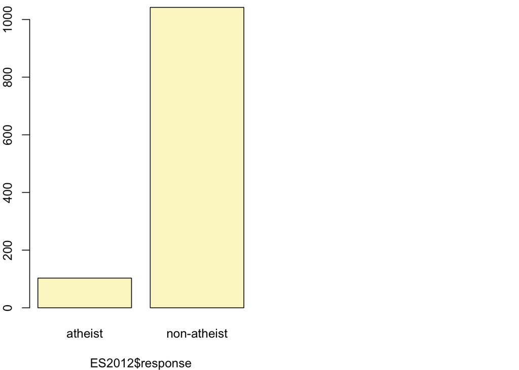

```
## p_hat = 0.09 ;  n = 1145
## Check conditions: number of successes = 103 ; number of failures = 1042
## Standard error = 0.0085
## 95 % Confidence interval = ( 0.0734 , 0.1065 )
```

Textual representation of the above information, where success is considered an atheist for simplicity sake:

```r
## Single proportion -- success: atheist
## Summary statistics: p_hat = 0.09 ;  n = 1145
## Check conditions: number of successes = 103 ; number of failures = 1042
## Standard error = 0.0085
## 95 % Confidence interval = ( 0.0734 , 0.1065 )
```

Alternatively, we could use `prop` (`test`/`table`) as demonstrated in the Week 6 demo. Included here for posterity:

```r
prop.test(50, n = 1145, conf.level = .95)$conf.int # n=1145, 1145 respondents
```

```
## [1] 0.03289963 0.05759983
## attr(,"conf.level")
## [1] 0.95
```

```r
prop.table(table(ES2012$nationality, ES2012$response))
```

```
##
##            atheist non-atheist
##   Spain 0.08995633  0.91004367
```

Create a dataframe for Spain 2005

```r
ES2005 <- subset(atheism, nationality == "Spain" & year == "2005") # Create a dataframe for 2005 Spain
ES2005$nationality <- factor(ES2005$nationality)
table(ES2005$nationality, ES2005$response)
```

```
##
##         atheist non-atheist
##   Spain     115        1031
```

No need to create a dataframe for Spain 2012, just included here for reference

```r
table(ES2012$nationality, ES2012$response)
```

```
##
##         atheist non-atheist
##   Spain     103        1042
```

As shown above, there were 115 atheists in 2005 and only 103 in 2012 (in the survey). We already have an inference for Spain 2012 from before but we’ll do it again; We have over 10 observations for atheists in 2005 and 2012, so it’s safe to use the `inference` function.

Spain in 2005:

```r
inference(ES2005$response, est = "proportion", type = "ci", method = "theoretical", success = "atheist")
```

```
## Single proportion -- success: atheist
## Summary statistics:
```

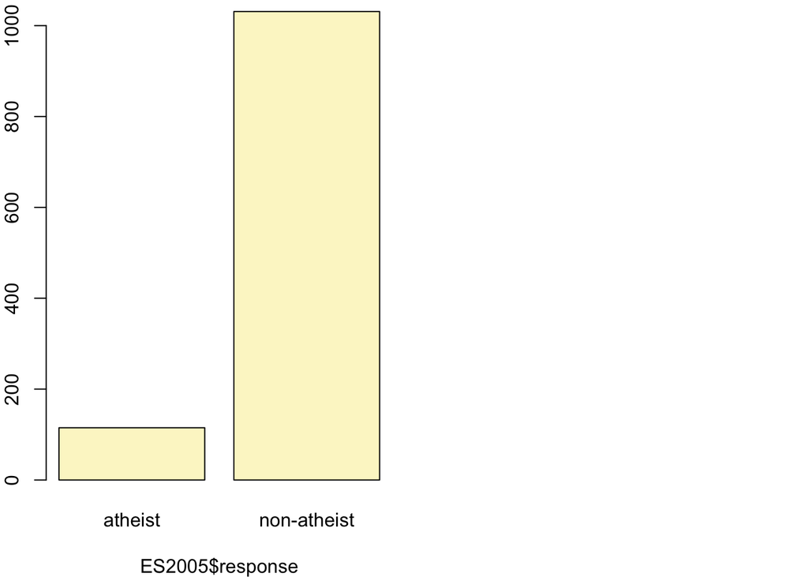

```
## p_hat = 0.1003 ;  n = 1146
## Check conditions: number of successes = 115 ; number of failures = 1031
## Standard error = 0.0089
## 95 % Confidence interval = ( 0.083 , 0.1177 )
```

Textual representation of the above information, where success is considered an atheist for simplicity sake:

```r
## Single proportion -- success: atheist
## Summary statistics: p_hat = 0.1003 ;  n = 1146
## Check conditions: number of successes = 115 ; number of failures = 1031
## Standard error = 0.0089
## 95 % Confidence interval = ( 0.083 , 0.1177 )
```

And for 2012:

```r
inference(ES2012$response, est = "proportion", type = "ci", method = "theoretical", success = "atheist")
```

```
## Single proportion -- success: atheist
## Summary statistics:
```

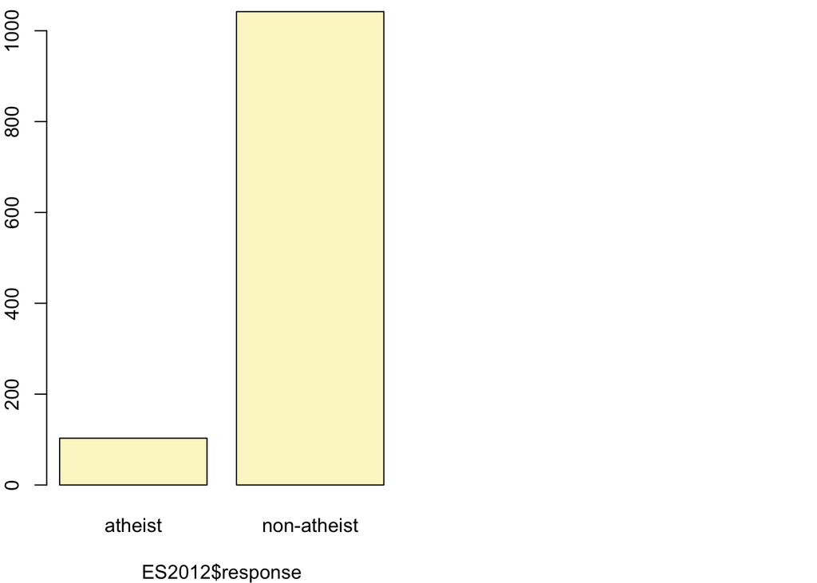

```
## p_hat = 0.09 ;  n = 1145
## Check conditions: number of successes = 103 ; number of failures = 1042
## Standard error = 0.0085
## 95 % Confidence interval = ( 0.0734 , 0.1065 )
```

Textual representation of the above information, where success is considered an atheist for simplicity sake:

```r
## Single proportion -- success: atheist
## Summary statistics: p_hat = 0.09 ;  n = 1145
## Check conditions: number of successes = 103 ; number of failures = 1042
## Standard error = 0.0085
## 95 % Confidence interval = ( 0.0734 , 0.1065 )
```

ANSWER 2: The confidence interval (CI) for the Spain 2012 frame is (0.0734, 0.1065), while the CI for the United States in 2012 is (0.0364, 0.0634) (Source: `Week 6 Demo Spring 2021.Rmd`). Both of these ranges were generated by a 95% CI using `inference()`. We can see clearly that the two do not overlap at all, and the higher range for Spain suggests that the population tends to lean more towards atheism.

```r
p_hat_2012 <- 0.09 # Using the most recent study from Spain (See Q1)
margin_error <- 0.01 # Margin of error allocated per the government
sample_size <- (1.96 ^ 2) * (p_hat_2012) * (1 - p_hat_2012) / (margin_error ^ 2) # Sample of residents needed
```

ANSWER 4: Because the number of atheists is less than 10 (it’s 8), we need to use bootstrapping to generate a larger representative sample. See below for the construction of the dataframe and bootstrapping methods.

```r
ZAF2012 <- subset(atheism, nationality == "South Africa" & year == "2012")
ZAF2012$nationality <- factor(ZAF2012$nationality)
table(ZAF2012$nationality, ZAF2012$response)
```

```
##
##                atheist non-atheist
##   South Africa       8         194
```

As mentioned in the lab and given by the table above, there are not 10 instances of each successes and failures (In this case, only 8 “successes” || 8 atheists). To address this, we can mimic the approach used in the `Week 6 Demo Spring 2021.Rmd` demonstration.

We need to include the required libraries/packages:

```r
library(infer)
library(tidyverse)
```

Now, we’ll combine knowledge from the previous Data Camp assignment and the demonstration mentioned above to create the bootstrapped samples. We’ll start with creating the bootstrap sample and visualizing it with a plot.

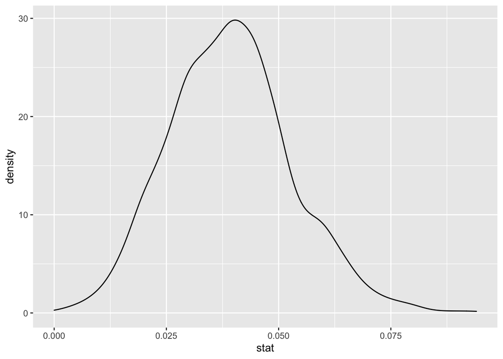

```r
boot_dist <- ZAF2012 %>%
  specify(response = response, success = "atheist") %>%
  generate(reps = 1000, type = "bootstrap") %>%
  calculate(stat = "prop")

ggplot(boot_dist, aes(x = stat)) +
  geom_density()
```

Moving on, now we need to find the standard error of the distribution to approximate a 95% CI.

```r
p_hat = 0.25
SE <- boot_dist %>%
  summarize(sd(stat)) %>%
  pull()
SE
```

```
## [1] 0.01367454
```

```r
c(p_hat - 2 * SE, p_hat + 2 * SE)
```

```
## [1] 0.2226509 0.2773491
```

Using the values generated above, we can generate a plot to visualize the SE/CI.

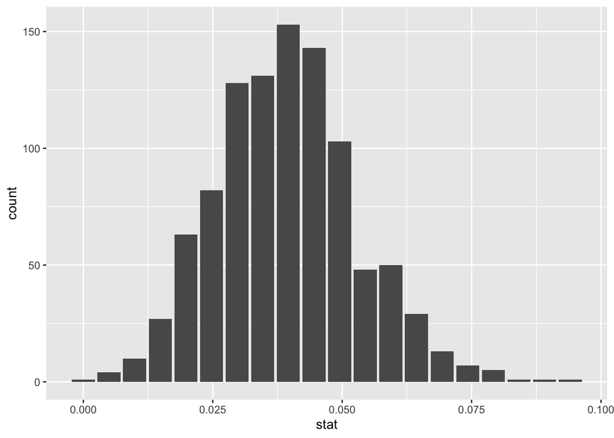

```r
ggplot(boot_dist, aes(x = stat)) +
  geom_bar()
```

Finally, using the 0.025 and 0.975 percentiles to define the edges of the CI.

```r
quantile(boot_dist$stat, c(0.025, 0.975))
```

```
##       2.5%      97.5%
## 0.01485149 0.06930693
```